# Interactive effect of temp and land use on nestling growth, nestling cort, and adult visitation rate

2025-01-28

## Revisiting growth ~ temp * habitat: WEBL

Inferential model (support in danny_meeting_20240213):

lmerTest::lmer(gweight_scaled ~ meanmaxtempI_scaled * habitat + poly(meanmintempI_scaled,2) * habitat + age + juliandate_scaled + (1|year) + (1|site/attempt_id))

Data wrangling:

dplyr::filter(g,Species == “WEBL”,!is.na(meanmaxtempI)) %>% mutate(across(c(gweight, meanmaxtempI, meanmintempI, juliandate, brood_size), ~ scale(.x)[,1],.names = “{.col}_scaled”), meanmaxtempI_scaled_sq = meanmaxtempI_scaled * meanmaxtempI_scaled))

## Predicted growth across temp and habitat: WEBL

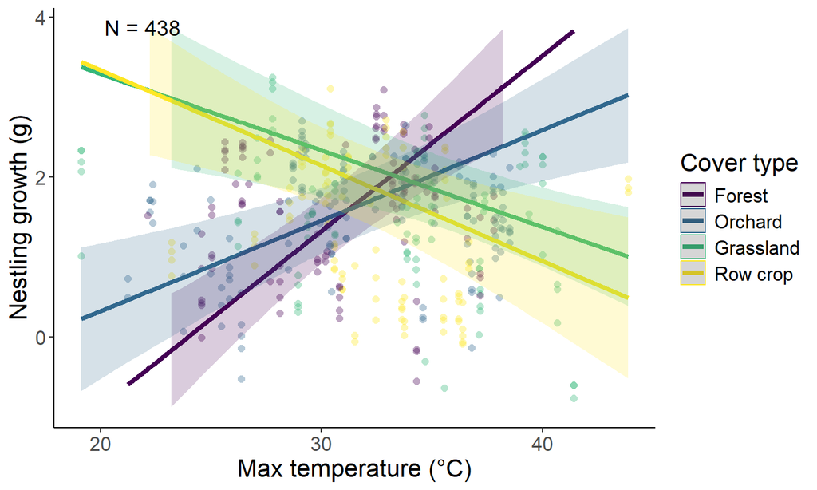

## Raw growth across max temp: WEBL

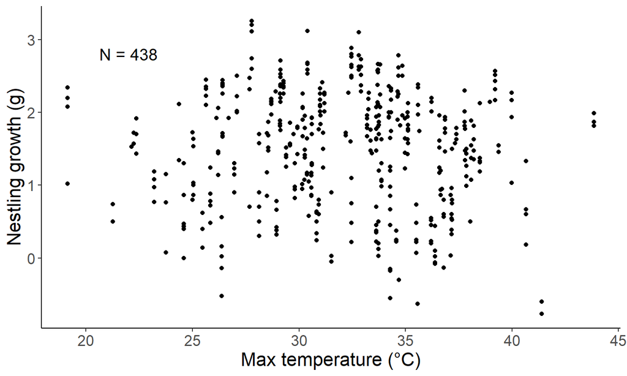

## Revisiting growth ~ temp * habitat: TRES

Inferential model (support in danny_meeting_20240213):

lmerTest::lmer(gweight_scaled ~ meanmaxtempI_scaled * habitat + poly(meanmintempI_scaled,2) * habitat + age + juliandate_scaled + (1|year) + (1|site/attempt_id))

Data wrangling:

dplyr::filter(g,Species == “TRES”, !is.na(meanmaxtempI)) %>% dplyr::filter(meanmaxtempI < 45) %>% mutate(across(c(gweight, meanmaxtempI, meanmintempI, juliandate, brood_size), ~ scale(.x)[,1], .names = “{.col}_scaled”), meanmaxtempI_scaled_sq = meanmaxtempI_scaled * meanmaxtempI_scaled))

## Predicted growth across temp and habitat: TRES

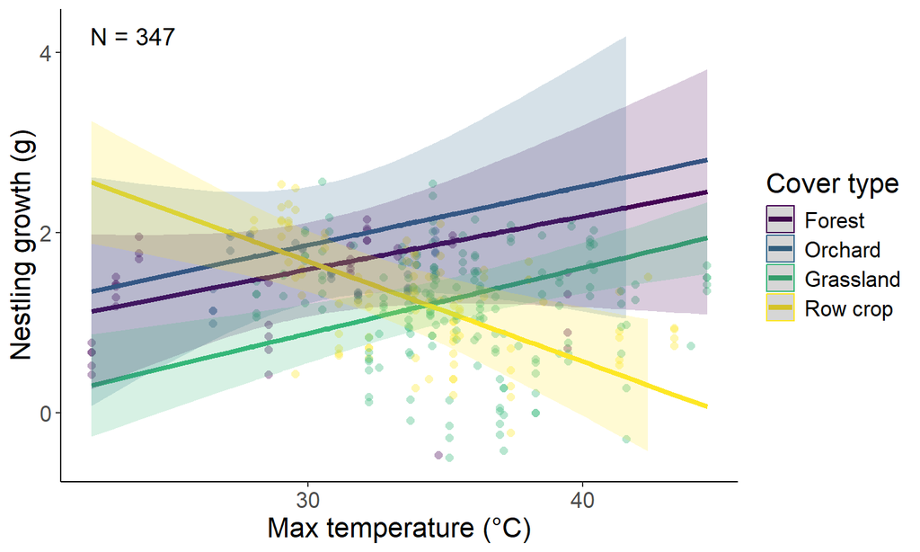

## Raw growth across max temp: TRES

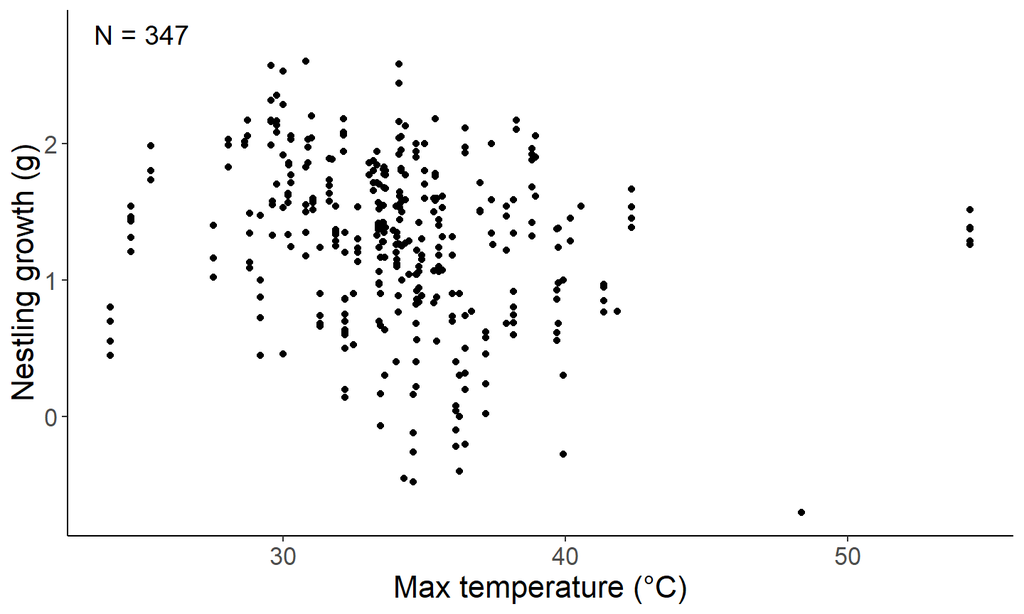

## Revisiting nestling cort ~ temp * habitat: WEBL

Base model:

cort_meanI_WEBL <- log(cort_s1) ~ poly(meanmaxtempI_scaled,2,raw = TRUE) * habitat + poly(meanmintempI_scaled,2) * habitat + poly(meanmaxtempI_scaled,2,raw = TRUE) * meanh_scaled + brood_size + age_scaled + juliandate_scaled + (1|year) + (1|site/attempt_id)

Need to answer two questions: - Is the interaction of temp and habitat significant? - Is the second-order term of max temp significant?

## Is interaction significant? (WEBL)

Models:

- no int: log(cort_s1) ~ habitat + poly(meanmaxtempI_scaled,2,raw = TRUE) + poly(meanmintempI_scaled,2) * habitat + poly(meanmaxtempI_scaled,2,raw = TRUE) * meanh_scaled + brood_size + age_scaled + juliandate_scaled + (1|year) + (1|site/attempt_id)
- linear int: log(cort_s1) ~ poly(meanmaxtempI_scaled,1,raw = TRUE) * habitat + poly(meanmaxtempI_scaled,2,raw = TRUE) + poly(meanmintempI_scaled,2) * habitat + poly(meanmaxtempI_scaled,2,raw = TRUE) * meanh_scaled + brood_size + age_scaled + juliandate_scaled + (1|year) + (1|site/attempt_id)
- squared int: log(cort_s1) ~ poly(meanmaxtempI_scaled,2,raw = TRUE) * habitat + poly(meanmintempI_scaled,2) * habitat + poly(meanmaxtempI_scaled,2,raw = TRUE) * meanh_scaled + brood_size + age_scaled + juliandate_scaled + (1|year) + (1|site/attempt_id)

| model | npar | AIC | BIC | logLik | deviance | Chisq | Df | Pr(>Chisq) |
| --- | --- | --- | --- | --- | --- | --- | --- | --- |
| no int | 24 | 210.1539 | 276.4461 | -81.07696 | 162.1539 | NA | NA | NA |
| linear int | 27 | 208.0437 | 282.6224 | -77.02187 | 154.0437 | 8.110183 | 3 | 0.04378859 |
| sq int | 30 | 209.7410 | 292.6062 | -74.87050 | 149.7410 | 4.302740 | 3 | 0.23057485 |

## Is squared term significant? (WEBL)

Models:

- no squared term: log(cort_s1) ~ poly(meanmaxtempI_scaled,1,raw = TRUE) * habitat + poly(meanmintempI_scaled,2) * habitat + poly(meanmaxtempI_scaled,2,raw = TRUE) * meanh_scaled + brood_size + age_scaled + juliandate_scaled + (1|year) + (1|site/attempt_id)
- no temp term: log(cort_s1) ~ habitat + poly(meanmintempI_scaled,2) * habitat + poly(meanmaxtempI_scaled,2,raw = TRUE) * meanh_scaled + brood_size + age_scaled + juliandate_scaled + (1|year) + (1|site/attempt_id)
- squared int: log(cort_s1) ~ poly(meanmaxtempI_scaled,2,raw = TRUE) * habitat + poly(meanmintempI_scaled,2) * habitat + poly(meanmaxtempI_scaled,2,raw = TRUE) * meanh_scaled + brood_size + age_scaled + juliandate_scaled + (1|year) + (1|site/attempt_id)

[output not shown]

Note to Danny: I’m not sure whether I should have removed the squared temp interaction with humidity or not.

## Inferential model cort ~ temp * habitat (WEBL)

log(cort_s1) ~ poly(meanmaxtempI_scaled,1,raw = TRUE) * habitat + poly(meanmintempI_scaled,2) * habitat + poly(meanmaxtempI_scaled,2,raw = TRUE) * meanh_scaled + brood_size + age_scaled + juliandate_scaled + (1|year) + (1|site/attempt_id)

| Predictor | Estimate | SE | P-value |
| --- | --- | --- | --- |
| (Intercept) | 1.50 | 0.92 | 0.1191 |
| poly(meanmaxtempI_scaled, 1, raw = TRUE) | 1.66 | 0.38 | 0.0000 |
| habitatOrchard | -0.14 | 0.45 | 0.7545 |
| habitatGrassland | -0.14 | 0.50 | 0.7844 |
| habitatRow crop | 0.06 | 0.37 | 0.8717 |
| poly(meanmintempI_scaled, 2)1 | -8.49 | 5.53 | 0.1291 |
| poly(meanmintempI_scaled, 2)2 | -4.77 | 3.10 | 0.1303 |
| poly(meanmaxtempI_scaled, 2, raw = TRUE)2 | 0.41 | 0.14 | 0.0048 |
| meanh_scaled | 0.05 | 0.16 | 0.7790 |
| brood_size | -0.02 | 0.20 | 0.9065 |
| age_scaled | 0.09 | 0.06 | 0.1309 |
| juliandate_scaled | -0.81 | 0.23 | 0.0019 |
| poly(meanmaxtempI_scaled, 1, raw = TRUE):habitatOrchard | -1.41 | 0.64 | 0.0321 |
| poly(meanmaxtempI_scaled, 1, raw = TRUE):habitatGrassland | -1.04 | 0.40 | 0.0114 |
| poly(meanmaxtempI_scaled, 1, raw = TRUE):habitatRow crop | -1.78 | 0.48 | 0.0004 |
| habitatOrchard:poly(meanmintempI_scaled, 2)1 | 20.15 | 8.90 | 0.0314 |
| habitatGrassland:poly(meanmintempI_scaled, 2)1 | 5.53 | 6.32 | 0.3837 |
| habitatRow crop:poly(meanmintempI_scaled, 2)1 | 16.42 | 6.17 | 0.0103 |
| habitatOrchard:poly(meanmintempI_scaled, 2)2 | -1.09 | 4.56 | 0.8127 |
| habitatGrassland:poly(meanmintempI_scaled, 2)2 | 3.59 | 7.06 | 0.6130 |
| habitatRow crop:poly(meanmintempI_scaled, 2)2 | 3.63 | 3.63 | 0.3240 |
| poly(meanmaxtempI_scaled, 2, raw = TRUE)1:meanh_scaled | 0.05 | 0.15 | 0.7169 |
| poly(meanmaxtempI_scaled, 2, raw = TRUE)2:meanh_scaled | 0.30 | 0.09 | 0.0014 |

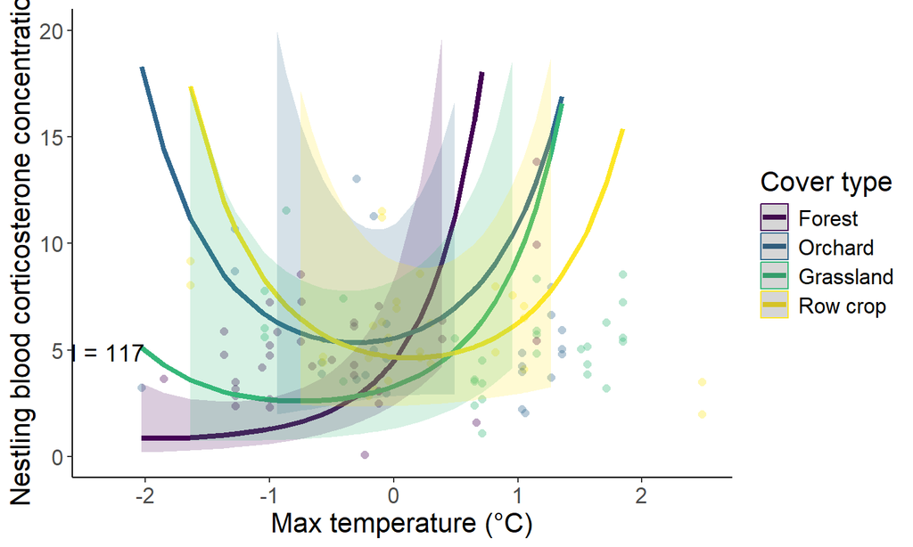

## Revisiting nestling cort ~ temp * habitat: TRES

Base model:

cort_meanI_TRES <- log(cort_s1) ~ poly(meanmaxtempI_scaled,2,raw = TRUE) * habitat + poly(meanmintempI_scaled,2) * habitat + poly(meanmaxtempI_scaled,2,raw = TRUE) * meanh_scaled + brood_size + age_scaled + juliandate_scaled + (1|year) + (1|site/attempt_id)

Need to answer two questions: - Is the interaction of temp and habitat significant? - Is the second-order term of max temp significant?

## Is interaction significant? (TRES)

Models:

- no int: log(cort_s1) ~ habitat + poly(meanmaxtempI_scaled,2,raw = TRUE) + poly(meanmintempI_scaled,2) * habitat + poly(meanmaxtempI_scaled,2,raw = TRUE) * meanh_scaled + brood_size + age_scaled + juliandate_scaled + (1|year) + (1|site/attempt_id)
- linear int: log(cort_s1) ~ poly(meanmaxtempI_scaled,1,raw = TRUE) * habitat + poly(meanmaxtempI_scaled,2,raw = TRUE) + poly(meanmintempI_scaled,2) * habitat + poly(meanmaxtempI_scaled,2,raw = TRUE) * meanh_scaled + brood_size + age_scaled + juliandate_scaled + (1|year) + (1|site/attempt_id)
- squared int: log(cort_s1) ~ poly(meanmaxtempI_scaled,2,raw = TRUE) * habitat + poly(meanmintempI_scaled,2) * habitat + poly(meanmaxtempI_scaled,2,raw = TRUE) * meanh_scaled + brood_size + age_scaled + juliandate_scaled + (1|year) + (1|site/attempt_id)

| model | npar | AIC | BIC | logLik | deviance | Chisq | Df | Pr(>Chisq) |
| --- | --- | --- | --- | --- | --- | --- | --- | --- |
| no int | 24 | 140.8577 | 201.6401 | -46.42887 | 92.85774 | NA | NA | NA |
| linear int | 27 | 141.1497 | 209.5298 | -43.57483 | 87.14965 | 5.708092 | 3 | 0.1267088 |
| sq int | 30 | 143.3108 | 219.2887 | -41.65538 | 83.31076 | 3.838894 | 3 | 0.2793944 |

## Is squared term significant? (TRES)

Models:

- no squared term: log(cort_s1) ~ poly(meanmaxtempI_scaled,1,raw = TRUE) * habitat + poly(meanmintempI_scaled,2) * habitat + poly(meanmaxtempI_scaled,2,raw = TRUE) * meanh_scaled + brood_size + age_scaled + juliandate_scaled + (1|year) + (1|site/attempt_id)
- no temp term: log(cort_s1) ~ habitat + poly(meanmintempI_scaled,2) * habitat + poly(meanmaxtempI_scaled,2,raw = TRUE) * meanh_scaled + brood_size + age_scaled + juliandate_scaled + (1|year) + (1|site/attempt_id)
- squared int: log(cort_s1) ~ poly(meanmaxtempI_scaled,2,raw = TRUE) * habitat + poly(meanmintempI_scaled,2) * habitat + poly(meanmaxtempI_scaled,2,raw = TRUE) * meanh_scaled + brood_size + age_scaled + juliandate_scaled + (1|year) + (1|site/attempt_id)

| model | npar | AIC | BIC | logLik | deviance | Chisq | Df | Pr(>Chisq) |
| --- | --- | --- | --- | --- | --- | --- | --- | --- |
| no temp | 20 | 135.1686 | 185.8206 | -47.58430 | 95.16861 | NA | NA | NA |
| no squared term | 25 | 142.8903 | 206.2053 | -46.44513 | 92.89026 | 2.278345 | 5 | 0.80944215 |
| sq int | 30 | 143.3108 | 219.2887 | -41.65538 | 83.31076 | 9.579508 | 5 | 0.08806507 |

Note to Danny: I’m not sure whether I should have removed the squared temp interaction with humidity or not.

## Inferential model cort ~ temp * habitat (TRES)

log(cort_s1) ~ habitat + poly(meanmaxtempI_scaled,2,raw = TRUE) + poly(meanmintempI_scaled,2) * habitat + poly(meanmaxtempI_scaled,2,raw = TRUE) * meanh_scaled + brood_size + age_scaled + juliandate_scaled + (1|year) + (1|site/attempt_id)

| Predictor | Estimate | SE | P-value |
| --- | --- | --- | --- |
| (Intercept) | 1.13 | 0.48 | 0.0253 |
| habitatOrchard | -0.78 | 0.55 | 0.1624 |
| habitatGrassland | -0.49 | 0.31 | 0.1261 |
| habitatRow crop | 0.13 | 0.94 | 0.8871 |
| poly(meanmaxtempI_scaled, 2, raw = TRUE)1 | 0.04 | 0.15 | 0.7792 |
| poly(meanmaxtempI_scaled, 2, raw = TRUE)2 | 0.03 | 0.08 | 0.7018 |
| poly(meanmintempI_scaled, 2)1 | -6.04 | 4.63 | 0.1954 |
| poly(meanmintempI_scaled, 2)2 | 4.55 | 5.06 | 0.3719 |
| meanh_scaled | -0.09 | 0.11 | 0.4586 |
| brood_size | 0.19 | 0.08 | 0.0136 |
| age_scaled | 0.09 | 0.06 | 0.1389 |
| juliandate_scaled | 0.16 | 0.09 | 0.0976 |
| habitatOrchard:poly(meanmintempI_scaled, 2)1 | 24.44 | 10.42 | 0.0218 |
| habitatGrassland:poly(meanmintempI_scaled, 2)1 | 3.75 | 4.41 | 0.3982 |
| habitatRow crop:poly(meanmintempI_scaled, 2)1 | -3.82 | 18.91 | 0.8406 |
| habitatOrchard:poly(meanmintempI_scaled, 2)2 | -16.89 | 10.16 | 0.1007 |
| habitatGrassland:poly(meanmintempI_scaled, 2)2 | -4.65 | 5.27 | 0.3802 |
| habitatRow crop:poly(meanmintempI_scaled, 2)2 | -0.66 | 10.84 | 0.9519 |
| poly(meanmaxtempI_scaled, 2, raw = TRUE)1:meanh_scaled | 0.02 | 0.11 | 0.8652 |
| poly(meanmaxtempI_scaled, 2, raw = TRUE)2:meanh_scaled | -0.02 | 0.04 | 0.5925 |

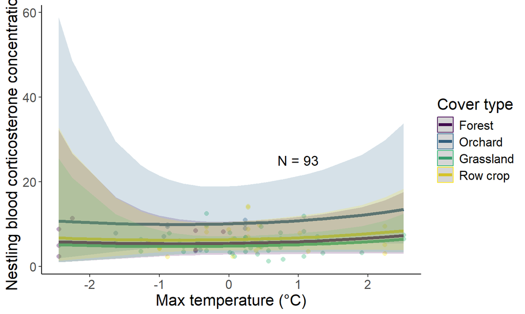

## New data! Provisioning ~ temp * habitat: WEBL

Used DAG version 3 in code/dag.Rmd to support model. Below model is canonical adjustment set given outcome = food provisioning and exposure = temp and habitat

Base model: provis ~ temp^2 * habitat + julian_date + nest_age + time_of_day^2 + 1|attempt_id + 1|year

Note: The model was not able to handle the nested random effect of site/attempt_id, so I figured attempt_id could soak up some of that variation and was the more important one. Should I also add folder as a random effect? That could soak up some of the sampling error (some cameras worked better than others, or had slightly different operation)

Need to answer two questions: - Is the interaction of temp and habitat significant? - Is the second-order term of max temp significant?

## Graphing base model (WEBL)

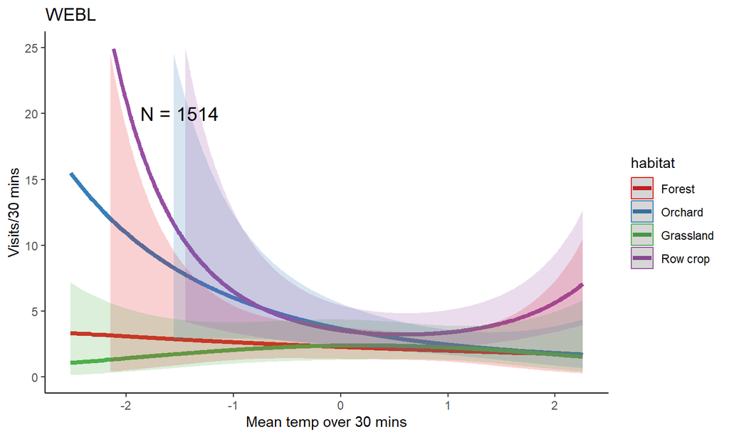

## Graphing base model (TRES)

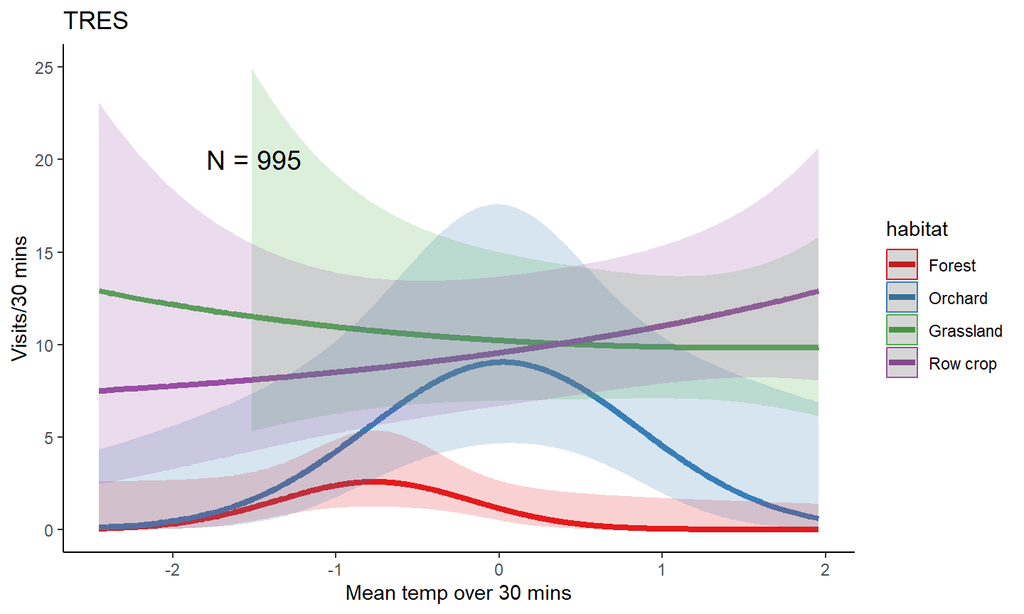

## Is the interaction of temp and habitat significant? (WEBL)

| model | Df | AIC | BIC | logLik | deviance | Chisq | Chi Df | Pr(>Chisq) |
| --- | --- | --- | --- | --- | --- | --- | --- | --- |
| no int | 14 | 5533.094 | 5607.609 | -2752.547 | 5505.094 | NA | NA | NA |
| linear | 17 | 5531.225 | 5621.708 | -2748.613 | 5497.225 | 7.868365 | 3 | 0.04881200 |
| sq int | 20 | 5530.007 | 5636.457 | -2745.003 | 5490.007 | 7.218333 | 3 | 0.06525493 |

## Is the squared term significant? (WEBL)

| model | Df | AIC | BIC | logLik | deviance | Chisq | Chi Df | Pr(>Chisq) |
| --- | --- | --- | --- | --- | --- | --- | --- | --- |
| no temp | 12 | 5534.954 | 5598.824 | -2755.477 | 5510.954 | NA | NA | NA |
| no squared term | 16 | 5535.139 | 5620.300 | -2751.570 | 5503.139 | 7.814089 | 4 | 0.09863068 |
| linear int term | 17 | 5531.225 | 5621.708 | -2748.613 | 5497.225 | 5.914248 | 1 | 0.01501891 |

[figure not shown]

## Is the interaction of temp and habitat significant? (TRES)

| model | Df | AIC | BIC | logLik | deviance | Chisq | Chi Df | Pr(>Chisq) |
| --- | --- | --- | --- | --- | --- | --- | --- | --- |
| no int | 14 | 4343.764 | 4412.402 | -2157.882 | 4315.764 | NA | NA | NA |
| linear | 17 | 4346.787 | 4430.133 | -2156.393 | 4312.787 | 2.976711 | 3 | 0.39522977 |
| sq int | 20 | 4344.031 | 4442.086 | -2152.016 | 4304.031 | 8.755683 | 3 | 0.03272191 |

## Is the squared term significant? (TRES)

| model | Df | AIC | BIC | logLik | deviance | Chisq | Chi Df | Pr(>Chisq) |
| --- | --- | --- | --- | --- | --- | --- | --- | --- |
| no temp | 12 | 4340.402 | 4399.235 | -2158.201 | 4316.402 | NA | NA | NA |
| no squared term | 16 | 4344.796 | 4423.239 | -2156.398 | 4312.796 | 3.606542 | 4 | 0.46186436 |
| squared int term | 20 | 4344.031 | 4442.086 | -2152.016 | 4304.031 | 8.764409 | 4 | 0.06726558 |

## Inferential model provis ~ temp^2 * habitat (TRES)

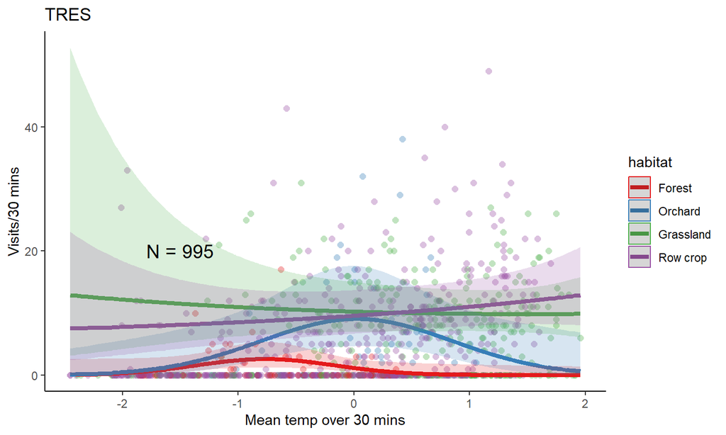